# Gene differential expression analysis

Chunhui

7/8/2019

## PART 1: Preparation: Packages & options

if you have problem about ‘could not find function’, make sure you got all the library first

## PART2: Data preparation

### 2.1 reading dataset from csv file

```r
head(table <- read.csv('kinetics_All_HD.csv', stringsAsFactors = F))
```

```
##           Geneid1      Geneid HD1_Blood HD2_Blood HD6_Blood HD1_1H HD2_1H
## 1 ENSG00000223972     DDX11L1         0         0         0      0      0
## 2 ENSG00000227232      WASH7P        56        51        57    105     85
## 3 ENSG00000278267   MIR6859-1         8         9        12      1      6
## 4 ENSG00000243485 MIR1302-2HG         0         0         0      0      0
## 5 ENSG00000284332   MIR1302-2         0         0         0      0      0
## 6 ENSG00000237613     FAM138A         0         0         0      0      0
##   HD6_1H HD1_2H HD2_2H HD6_2H HD1_4H HD2_4H HD6_4H HD1_6H HD2_6H HD6_6H
## 1      0      0      0      0      1      0      0      0      0      0
## 2     31     64     30     18     41     45     17     40     48    118
## 3      1      2      0      3      0      0      6      1      0     28
## 4      0      0      0      0      0      0      0      0      0      0
## 5      0      0      0      0      0      0      0      0      0      0
## 6      0      0      0      0      0      0      0      0      0      0
```

### 2.2 Get external

For further analysis, we need to get `external gene name` from `ensenble gene id` as possible as we can. By nature, `external gene name` and `ensenble gene id` are not one-to-one relationship, e.g. multiple `external gene names` could correspond to one `external gene name`

To do this, we need library `BiomaRt`.

List available `Mart` by use `listMarts`, then create ensembl objection by using `useMart`. Use `listDatasets` with ensembl objection as parameter to get available gene dataset

Create Mart object by using `useDataset` with corresponding `ensemble` and `gene dataset`. `listFilters` would list all the available filters

For more information about `biomaRt`, run **browseVignettes(‘biomaRt’)**

use `getBM` with correct filter and attributes to get corresponding `external gene name` from `ensemble gene id`

**This procedure could take a long time depending how large your dataset and you network speed**

```r
G_list_2 <- read.xlsx2(file = 'G_list.xlsx', sheetIndex = 1)
```

## rebuild dataset

left join original dataset `table` with `G_list`, for those `ensembl gene name` don’t have `external gene name` , using their `ensemble gene name` instead.

```r
table_merge <- sqldf::sqldf('select *
             from "table"
             left join G_list_2 on "table".Geneid1 = G_list_2.ensembl_gene_id')
table_reordered <- table_merge %>%
  as_tibble() %>%
   dplyr::select(Geneid1, external_gene_name, everything())
#remove useless column
table_reordered <- table_reordered[, c(-3, -19)]
table_reordered$external_gene_name <-
  ifelse(is.na(table_reordered$external_gene_name),table_reordered$Geneid1,
         table_reordered$external_gene_name)

head(table_reordered)
```

```
## # A tibble: 6 x 18
##   Geneid1 external_gene_n~ HD1_Blood HD2_Blood HD6_Blood HD1_1H HD2_1H
##   <chr>   <chr>                <int>     <int>     <int>  <int>  <int>
## 1 ENSG00~ DDX11L1                  0         0         0      0      0
## 2 ENSG00~ WASH7P                  56        51        57    105     85
## 3 ENSG00~ MIR6859-1                8         9        12      1      6
## 4 ENSG00~ MIR1302-2HG              0         0         0      0      0
## 5 ENSG00~ MIR1302-2                0         0         0      0      0
## 6 ENSG00~ FAM138A                  0         0         0      0      0
## # ... with 11 more variables: HD6_1H <int>, HD1_2H <int>, HD2_2H <int>,
## #   HD6_2H <int>, HD1_4H <int>, HD2_4H <int>, HD6_4H <int>, HD1_6H <int>,
## #   HD2_6H <int>, HD6_6H <int>, ensembl_gene_id <chr>
```

keep only `Geneid` column

```r
table_geneid <- table_reordered[,-1]
colnames(table_geneid)[1] = 'Geneid'
# omit any row if has missing value
# Caution! this may not the best method
head(table_geneid)
```

```
## # A tibble: 6 x 17
##   Geneid HD1_Blood HD2_Blood HD6_Blood HD1_1H HD2_1H HD6_1H HD1_2H HD2_2H
##   <chr>      <int>     <int>     <int>  <int>  <int>  <int>  <int>  <int>
## 1 DDX11~         0         0         0      0      0      0      0      0
## 2 WASH7P        56        51        57    105     85     31     64     30
## 3 MIR68~         8         9        12      1      6      1      2      0
## 4 MIR13~         0         0         0      0      0      0      0      0
## 5 MIR13~         0         0         0      0      0      0      0      0
## 6 FAM13~         0         0         0      0      0      0      0      0
## # ... with 8 more variables: HD6_2H <int>, HD1_4H <int>, HD2_4H <int>,
## #   HD6_4H <int>, HD1_6H <int>, HD2_6H <int>, HD6_6H <int>,
## #   ensembl_gene_id <chr>
```

## resolve duplicates

Since the transformation from `ensemble gene id` and `external gene name` is not one-to-one, so `Geneid` is not unique, to transform dataset into a matrix with row name, `Geneid` must be `unique` ** for duplicates `Geneid`, take the mean of each column into one row**

```r
#remove depublicate by geneid using sqlite
# base rule: average the read from the same gene
# caution! This may not applicable for bio-duplicate
table_nodup <-  sqldf::sqldf('
  select Geneid,
         avg(HD1_Blood) as HD1_Blood, avg(HD2_Blood) as HD2_Blood, avg(HD6_Blood) as HD6_Blood,
         avg(HD1_1H) as HD1_1H, avg(HD2_1H) as HD2_1H, avg(HD6_1H) as HD6_1H,
         avg(HD1_2H) as HD1_2H, avg(HD2_2H) as HD2_2H, avg(HD6_2H) as HD6_2H,
         avg(HD1_4H) as HD1_4H, avg(HD2_4H) as HD2_4H, avg(HD6_4H) as HD6_4H,
         avg(HD1_6H) as HD1_6H, avg(HD2_6H) as HD2_6H, avg(HD6_6H) as HD6_6H
  from table_geneid
  group by Geneid
  order by Geneid
  '
)
head(table_nodup)
```

```
##     Geneid HD1_Blood HD2_Blood HD6_Blood HD1_1H HD2_1H HD6_1H HD1_2H
## 1     A1BG         4         0         0      0      0      0      0
## 2 A1BG-AS1         2         2         4      2      2      0      3
## 3     A1CF         0         0         0      0      0      0      0
## 4      A2M         9        17         4      4      5      5      6
## 5  A2M-AS1         0         0         0      0      2      0      2
## 6    A2ML1         2         1         0      2      0      0      0
##   HD2_2H HD6_2H HD1_4H HD2_4H HD6_4H HD1_6H HD2_6H HD6_6H
## 1      0      0      0      0      0      0      2      4
## 2     24      2      6     15      0     15     13      8
## 3      1      0      0      2      0      0      0      4
## 4      0      3      0      1      2      0      0      0
## 5      2      0     11      4      0      2      7      8
## 6      2      0      2      8     17      2      0      2
```

Double check whether there is no duplicates

```r
#check how many gene left in the processed dataset
length(table_nodup$Geneid)
```

```
## [1] 56682
```

```r
#check whether there is duplicate now, if there is no duplicate, a True should be returen
all(!duplicated(table_nodup[,1]))
```

```
## [1] TRUE
```

## PART 3: Using DESeq2

`DESque2` is the updated version of `DESque`, You may have different type of orginal file, `DESeq2` has different data preparation solutions for them. For more information,m run **browseVignettes(‘DESeq’)**

### 3.1 Data preparation

make the matrix needed for next step

```r
#make the matrix needed for next step
#use the geneid as row.names
table_rownames <- data.frame(table_nodup[,-1], row.names=table_nodup[,1])
count_maxtrix <- as.matrix(table_rownames)
# make the mode of matrix integer otherwise it will be number
mode(count_maxtrix) <- 'integer'
head(count_maxtrix)
```

```
##          HD1_Blood HD2_Blood HD6_Blood HD1_1H HD2_1H HD6_1H HD1_2H HD2_2H
## A1BG             4         0         0      0      0      0      0      0
## A1BG-AS1         2         2         4      2      2      0      3     24
## A1CF             0         0         0      0      0      0      0      1
## A2M              9        17         4      4      5      5      6      0
## A2M-AS1          0         0         0      0      2      0      2      2
## A2ML1            2         1         0      2      0      0      0      2
##          HD6_2H HD1_4H HD2_4H HD6_4H HD1_6H HD2_6H HD6_6H
## A1BG          0      0      0      0      0      2      4
## A1BG-AS1      2      6     15      0     15     13      8
## A1CF          0      0      2      0      0      0      4
## A2M           3      0      1      2      0      0      0
## A2M-AS1       0     11      4      0      2      7      8
## A2ML1         0      2      8     17      2      0      2
```

```r
#create the coldata corresponding to the processed dataset
coldata <- data.frame(condition = c(rep('blood', 3),
                                    rep('1h', 3),
                                    rep('2h', 3),
                                    rep('4h', 3),
                                    rep('6h', 3)),
                      row.names = colnames(count_maxtrix)[1:15])
head(coldata)
```

```
##           condition
## HD1_Blood     blood
## HD2_Blood     blood
## HD6_Blood     blood
## HD1_1H           1h
## HD2_1H           1h
## HD6_1H           1h
```

It is absolutely critical that the columns of the count matrix and the rows of the column data (information about samples) are in the same order. DESeq2 will not make guesses as to which column of the count matrix belongs to which row of the column data, these must be provided to DESeq2 already in consistent order.

```r
#check whether the name of row match col, a True should be returned
all(rownames(coldata) == colnames(count_maxtrix)[1:15])
```

```
## [1] TRUE
```

```r
#create DESeqDataSet(dds) object, dds is a container for intermediate data
dds <- DESeqDataSetFromMatrix(countData = count_maxtrix[,1:15],
                              colData = coldata,
                              design = ~ condition)
```

### 3.2 pre-filtering

```r
# pre-filtering
# by removing rows in which there are very few reads, we reduce the memory size of the dds data object,
#   and we increase the speed of the transformation and testing functions within DESeq2
keep <- rowSums(counts(dds)) >= 10
dds <- dds[keep,]

# set dds condition with all time points
# set 'blood' as base level, the default base level is determined by alphabet order
# other statement if also available for this purpose
# Caution!: the document only give example for factor with two levels, not sure about accuracy for
#   factor with more than 2 levels
dds$condition <- factor(dds$condition, levels = c("blood","1h",'2h', '4h', '6h'))
# drop levels that with no sample
dds$condition <- droplevels(dds$condition)
```

## PArt 4: Defferential Expression Analysis

### 4.1 Create dds object

```r
# DEseq analysis
dds <- DESeq(dds)
# for different condition you just change 6h to i.e. 1h, 2h, 4h
# may can be done by lapply() function, not sure how to set the func argument
# with different arguments
res_1h <- results(dds,contrast=c("condition","1h","blood"))
res_2h <- results(dds,contrast=c("condition","2h","blood"))
res_4h <- results(dds,contrast=c("condition","4h","blood"))
res_6h <- results(dds,contrast=c("condition","6h","blood"))
resultsNames(dds)
```

```
## [1] "Intercept"             "condition_1h_vs_blood" "condition_2h_vs_blood"
## [4] "condition_4h_vs_blood" "condition_6h_vs_blood"
```

### 4.2 Build Function for subset result

`res_subgroup` is a useful function to subset the result from DESeq, it has 4 parameter `res` is an instance of DESeq.result object `alpha` is the boundary for adjusted p-value, default 0.1 if not specified. `reg_dir` is the direction of your `alpha` value, ‘all’, ‘up’ and ‘down’ can be used. all – up and down regulated up – up regulated only down – down regulated only

```r
# this function is used to subset the neeeded gene from RESULT object
#function get those LFC greate than 1 and the adjusted P-value is less than 0.1
res_subgroup <- function(res, alpha=0.1, reg_LFC=1, reg_dir='all'){

  # res is an obj from DEseq2.result function
  # alpha gives the significant level for adjusted P-value
  # reg gives the regulation level change in log2 fold change in absolute value
  # reg_dir gives which regulation direction you want to subset you gene
    # three options: all -- up and down
    #                up  -- only up regulated
    #                down -- only down regulated
  res_sig_pos <- (res$padj < alpha)
  res_sig_pos[is.na(res_sig_pos)] <- F
  if(reg_dir == 'all'){
    res_LFC_pos <- (res$log2FoldChange > reg_LFC) | (res$log2FoldChange < -reg_LFC)
  }
  else if(reg_dir == 'up'){
           res_LFC_pos <- (res$log2FoldChange > reg_LFC)
       }
       else if(reg_dir == 'down'){
                res_LFC_pos <- (res$log2FoldChange < -reg_LFC)
            }

  return(res[res_LFC_pos & res_sig_pos,])

}
```

You can use `lapply` to apply a function to a list of dataset togather of different `condition`, e.g. 1h_vs_blood, 2h_vs_blood, 4h_vs_blood and 6h_vs_blood

```r
#get all 4 upregluated genes
res_list <- list(res_1h,res_2h,res_4h,res_6h)
res_list_up <- lapply(res_list, res_subgroup, reg_dir ='up')
#get all 4 downregluated genes
res_list_down <- lapply(res_list, res_subgroup, reg_dir ='down')
```

## PART 5: Analysis and plot

### 5.1 Plot MA-plot

use `plotMA` function with a `result` object as parameter

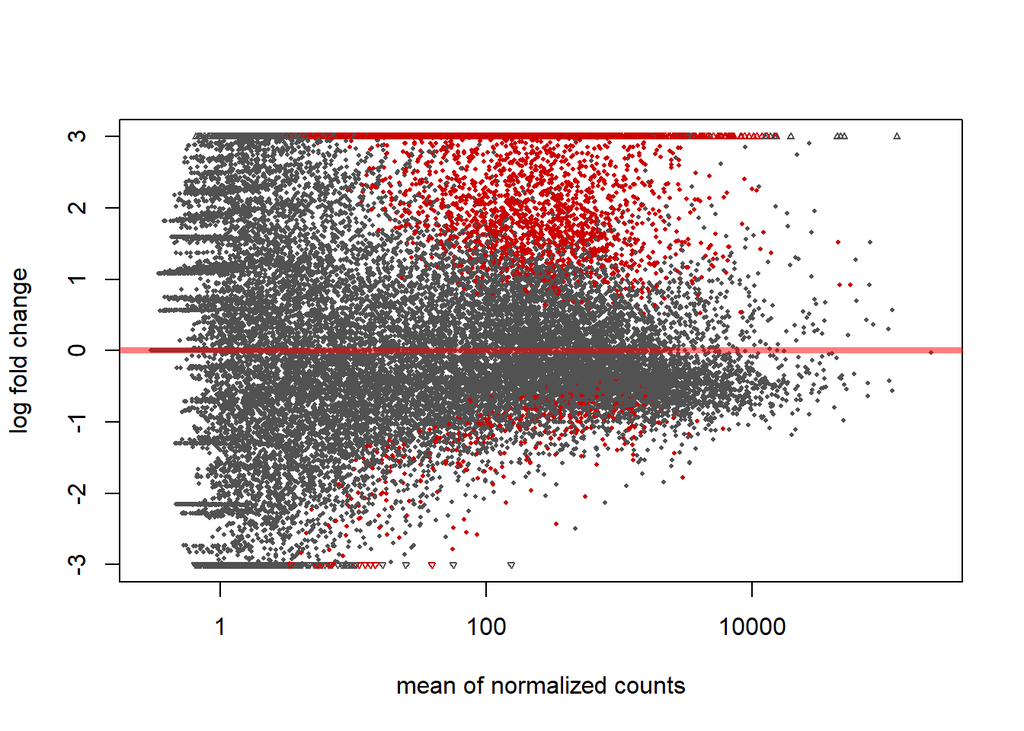

```r
# plot the MAplot with the subset result
plotMA(res_1h, ylim=c(-3,3))
```

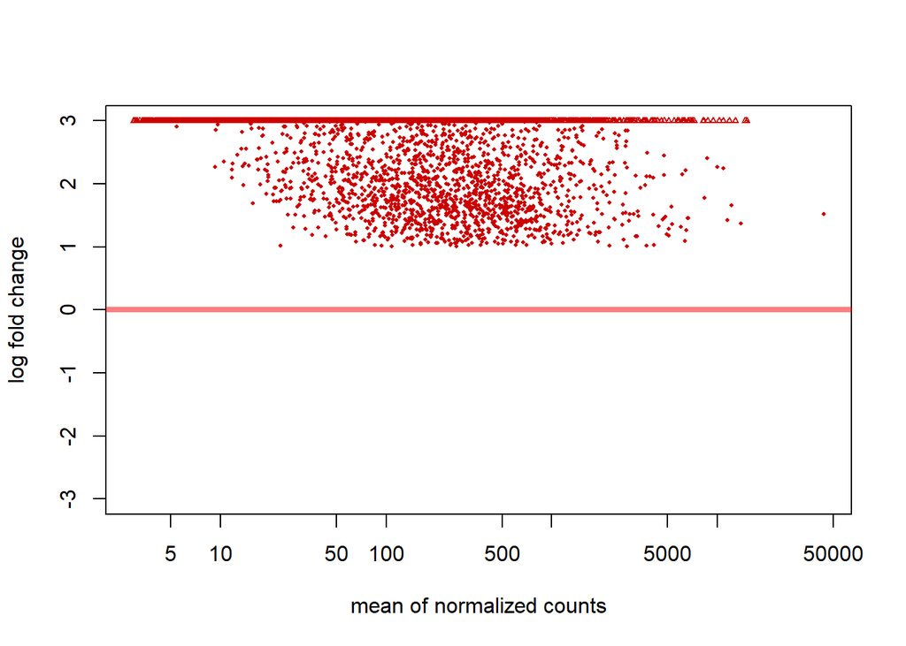

```r
plotMA(res_list_up[[1]], ylim=c(-3,3))
```

### 5.2 Correlation

This is a demo for correlation gene in a list `overlap transcriptome proteome.xlsx` of **expression of proteomics**(`Proteomics.xlsx`) and **expression of RNAseq**(`10hr_normed_counts.xlsx`).

First we need to get the RNAseq and proteomics level from two data files.

```r
# correlation analysis
#read in data as tibble
proteomics <- read.xlsx2(file = 'Proteomics.xlsx', sheetName = 'Sheet1', stringsAsFactors = F,
                         colClasses = c('character', 'character', rep("double", 9))
                         ) %>%
  as_tibble()

count_10h <- read.xlsx2(file = '10hr_normed_counts.xlsx', sheetName = 'counts',
                        colClasses = c('character', rep("double", 16))) %>%
  as_tibble()

# delete the '_HUMAN' suffix in the GENE.ID variable of proteomics dataset.
proteomics$GENE.ID <- sapply(proteomics$GENE.ID, sub, pattern = '_HUMAN', replacement = '')

#
intersc <- intersect(proteomics$GENE.ID, count_10h$ID)
x <- count_10h[count_10h$ID %in% intersc, ] %>%
  dplyr::select(ID,CFASN_TM_1:CFASN_TM_3)
y <- proteomics[proteomics$GENE.ID %in% intersc,] %>%
  dplyr::select(GENE.ID,CFASN_1:CFASN_3)
```

Read in the list of genes need to analyze correlation.

```r
intersc.up <- as.list(read.xlsx2('overlap transcriptome proteome.xlsx', header = F,
                                 sheetIndex = 1, stringsAsFactors = F))
```

```r
##get the correaltions of transcriptomics and proteinomics of intersection genes
# Initiate data frame of correlation results
correlations <- data.frame(matrix(NA, nrow=length(x$ID), ncol=6))
# Assign the first column as the protein names and their site (B2/B4) subset
correlations[ ,1] <- x[,1]
# Assign column names
colnames(correlations) <- c("gene", "Sample Size", "Pearson CC", "Pearson P-Value",
                            "Spearman Rho", "Spearman P-Value")

for (i in 1:nrow(correlations)) {
  cor.pearson <- cor.test(as.numeric(x[i,][,2:4]), as.numeric(y[i,][,2:4]))
  cor.spearman <- cor.test(as.numeric(x[i,][,2:4]), as.numeric(y[i,][,2:4]), method = 'spearman')
  #Col 2. Sample size
  correlations[i,2] <- as.integer(cor.pearson$parameter) + 2
  #Col 3. pcc
  correlations[i,3] <- as.numeric(cor.pearson$estimate)
  #Col 4. pcc p-value
  correlations[i,4] <- as.numeric(cor.pearson$p.value)
  #Col 6. spearman's rho
  correlations[i,5] <- as.numeric(cor.spearman$estimate )
  #Col 7. spearman's rho p-value
  correlations[i,6] <- as.numeric(cor.spearman$p.value )
}
```

Due to the small sample size, most of points has a large P-value, you can use the code commented to get those with p-value < 0.05

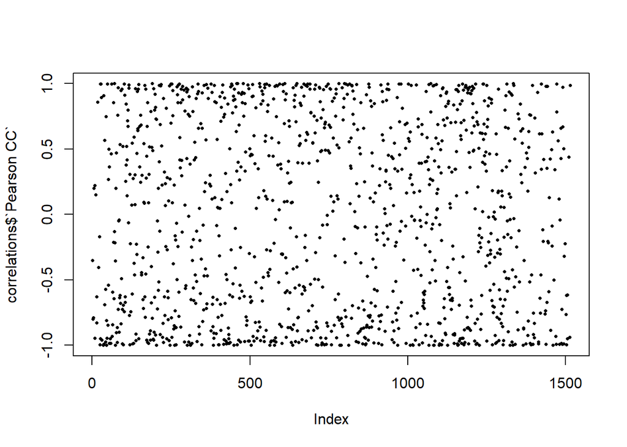

```r
#correlations$`Pearson CC`[which(correlations$`Pearson P-Value` < 0.05)]
plot(correlations$`Pearson CC`, pch = 16, cex = 0.5)
```

### 5.3 plot trend through time

First get the data we need

```r
library(ggplot2)
library(tidyr)
dat <- NULL
dat$time <- as.factor(c('1h', '2h', '4h', '6h'))
#get the number of genes which have significant differential expression
dat$down <- sapply(res_list_down, nrow)
dat$up <- sapply(res_list_up, nrow)
dat <- as.data.frame(dat)
```

The plot show the there is a huge increase of # of down-regulated genes

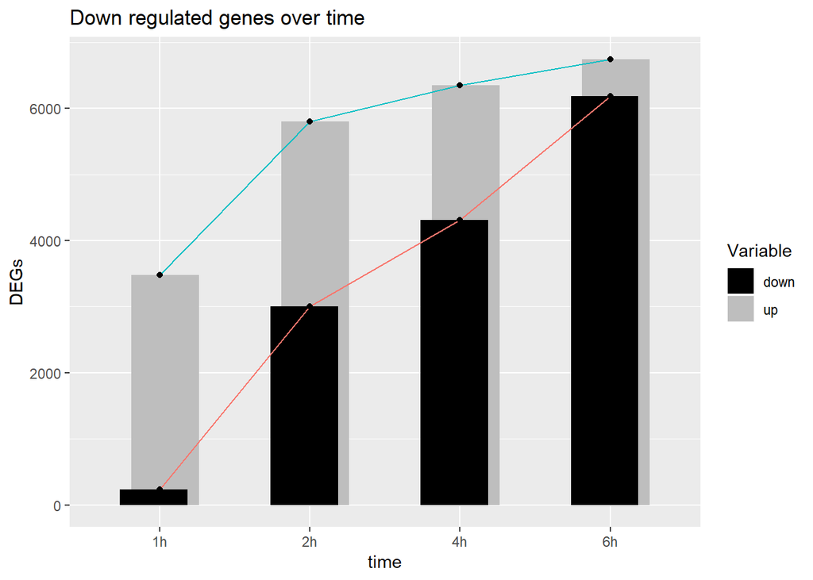

```r
# gather function is useful to takes multiple columns and collapses into key-value pairs
ggplot(data = dat %>% gather(Variable, reg, -time),
       aes(x = time, y = reg, fill = Variable)) +
  geom_bar(stat = 'identity', position = position_dodge(width = 0.15)) +
  geom_line(aes(x = time, y = reg, group = Variable, color = Variable),
            stat="identity", show.legend = F) +
  geom_point(show.legend = F) +
  scale_fill_manual(values=c("black", "grey")) +
  labs(title = "Down regulated genes over time", x = "time", y = "DEGs")
```

### 5.4 Bubble plot

Bubble plot for gene enrichment analysis. Data preparation for the bubble plot.

```r
data.tf.enrich <- read.xlsx2(file = 'Enrichment figures R Chunhui.xlsx',
                                   sheetName = 'TF',
                                   colClasses = c('character','numeric','character', rep('numeric', 4))
)

head(data.tf.enrich)
```

```
##       Gene.Set.Name X..Genes.in.Gene.Set..K.
## 1     CAGGTG_E12_Q6                     2485
## 2    GGGCGGR_SP1_Q6                     2940
## 3   GGGAGGRR_MAZ_Q6                     2274
## 4    CTTTGT_LEF1_Q2                     1972
## 5     TGANTCA_AP1_C                     1121
## 6 TGGAAA_NFAT_Q4_01                     1896
##                                                                                                                                                             Description
## 1     Genes having at least one occurence of the highly conserved motif M12 CAGGTG sites. The motif matches transcription factor binding site V$E12_Q6 (v7.4 TRANSFAC).
## 2     Genes having at least one occurence of the highly conserved motif M6 GGGCGGR sites. The motif matches transcription factor binding site V$SP1_Q6 (v7.4 TRANSFAC).
## 3   Genes having at least one occurence of the highly conserved motif M24 GGGAGGRR sites. The motif matches transcription factor binding site V$MAZ_Q6 (v7.4 TRANSFAC).
## 4    Genes having at least one occurence of the highly conserved motif M13 CTTTGT sites. The motif matches transcription factor binding site V$LEF1_Q2 (v7.4 TRANSFAC).
## 5      Genes having at least one occurence of the highly conserved motif M7 TGANTCA sites. The motif matches transcription factor binding site V$AP1_C (v7.4 TRANSFAC).
## 6 Genes having at least one occurence of the highly conserved motif M55 TGGAAA sites. The motif matches transcription factor binding site V$NFAT_Q4_01 (v7.4 TRANSFAC).
##   X..Genes.in.Overlap..k.    k.K  p.value FDR.q.value
## 1                     266 0.1070 2.34e-72    1.44e-69
## 2                     268 0.0912 2.15e-58    6.63e-56
## 3                     223 0.0981 2.04e-53    4.18e-51
## 4                     184 0.0933 8.47e-41    1.30e-38
## 5                     128 0.1142 5.00e-37    6.15e-35
## 6                     172 0.0907 1.52e-36    1.56e-34
```

Your enrichment data may looks like this.

```r
data.tf.enrich$Gene.Set.Name <- paste('                               ', data.tf.enrich$Gene.Set.Name)
data.tf.enrich$FDR.q.value = -log10(as.numeric(data.tf.enrich$FDR.q.value))
#order the data by # of genes overlaped
data.tf.enrich$Gene.Set.Name <- factor(data.tf.enrich$Gene.Set.Name,                                              levels=data.tf.enrich$Gene.Set.Name[order(data.tf.enrich$X..Genes.in.Overlap..k.)])
```

The color indicates `FDR q value`. The size of circle indicates `# of genes overlaped`.

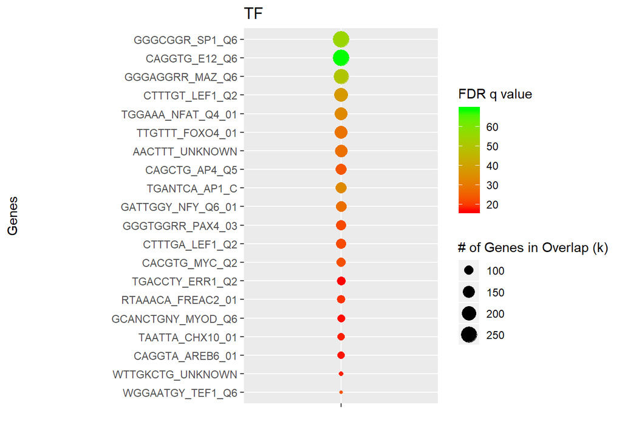

```r
ggplot(data = data.tf.enrich) +
  geom_point(aes(x = data.tf.enrich$Gene.Set.Name, y='', size =  X..Genes.in.Overlap..k., color = FDR.q.value)) +
  coord_flip() +
  labs(title = 'TF', size = '# of Genes in Overlap (k)', color = 'FDR q value') +
  ylab('') +
  xlab('Genes') +
  scale_colour_gradient(low = "red", high = "green") +
  scale_size(breaks = c(50, 100, 150, 200, 250)) +
  theme(legend.position = "right")
```

# 5.5 heatmap

Heatmap for a list of genes `heatmap CF upregulated.xlsx` among the four time points First, get the matrix for heatmap.

```r
gene_intsc.table <- read.xlsx2(file = 'heatmap CF upregulated.xlsx', sheetIndex = 1,
                               stringsAsFactors = F, header = F)

lfc_ts_expr.tibble <- tibble(gene_name = rownames(res_1h),
      lfc.1h = res_1h$log2FoldChange,
      lfc.2h = res_2h$log2FoldChange,
      lfc.4h = res_4h$log2FoldChange,
      lfc.6h =res_6h$log2FoldChange)

#filter genes and create matrix with column names
gene_intsc_heatmap.tibble <- lfc_ts_expr.tibble %>%
  dplyr::filter(gene_name %in% gene_intsc.table[,1])
gene_intsc_heatmap.matrix <- as.matrix(gene_intsc_heatmap.tibble[,2:5])

# set the row names for matrix
rownames(gene_intsc_heatmap.matrix) <- as.vector(as.list(gene_intsc_heatmap.tibble[,1])[[1]])
```

**You may need to zoom or set resolution in export to see gene name clearly**

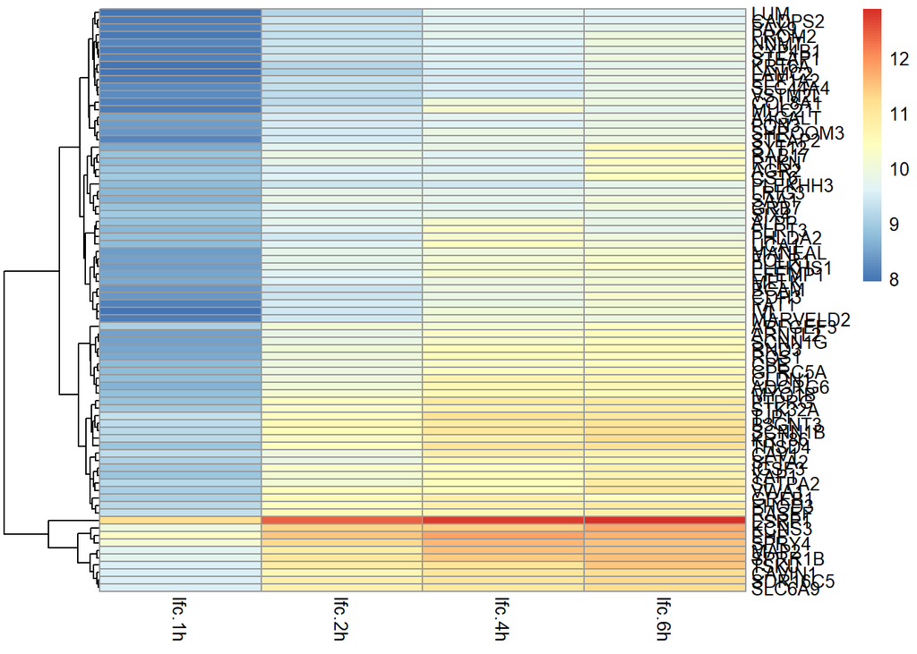

```r
pheatmap(gene_intsc_heatmap.matrix, cluster_cols = F)
```

`pheatmap` and `heatmap.2` are two function available to plot heatmap. see package `pheatmap` and `gplots` for more details.

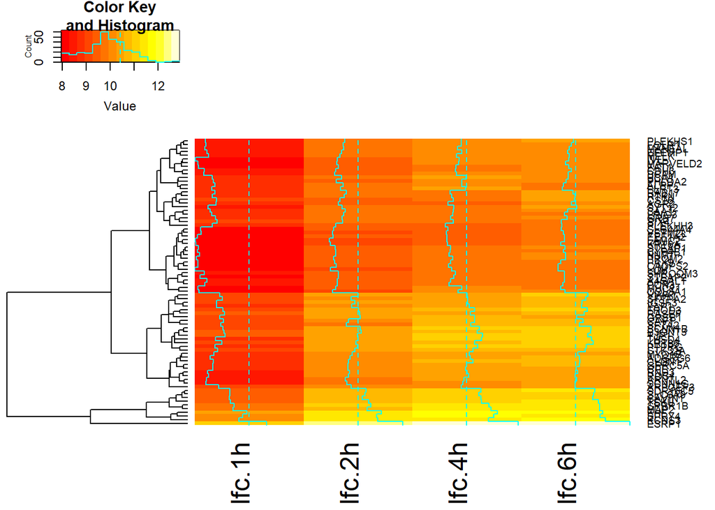

```r
# Since we don't need column cluster, we set Colv = FALSE and dendrogram = 'row'
heatmap.2(gene_intsc_heatmap.matrix, Colv = FALSE, dendrogram = 'row')
```